# Social Network Analysis

Alexandre Olivier - Cedric Viret

```r
options(warn=-1)
library(igraph)
library(data.table)
library(dplyr)
library(ggplot2)
```

## Loading data and basic description

In this second assignment, we will use a new dataset, Twitter activity around a rumor. In particular, in your dataset, you will find RTs between users, in this format:

- First column: retweeting user
- Second column: retweeted user
- Third column: timestamp

As we did in our first assignment you have to:

- Load the dataset
- Build the original graph object. Your resulting graph must be directed (and be careful with the direction during the rest of the assignment)
- We are NOT going to simplify this graph
- We are NOT going to keep only the largest connected component

After loading your data you have to describe your graph in a paragraph, mentioning how many nodes and edges it has, how many connected components and how they are (both weak and strong), and how the degree distribution is (is it power law?) for both, in and out degree. Additionally, compute the global clustering and reciprocity for this graph. Interpret your results.

```r
# reading file
df = fread("higgs-activity_time_RTS.txt")
str(df)
```

```
## Classes 'data.table' and 'data.frame':   354930 obs. of  3 variables:
##  $ user1: int  376989 376989 453850 99258 75083 325821 104321 408376 247125 224480 ...
##  $ user2: int  50329 13813 8 50329 84647 8 238279 8 463 93318 ...
##  $ ts   : int  1341101181 1341101192 1341101208 1341101263 1341101732 1341102141 1341102794 1341102802 1341103262 1341103333 ...
##  - attr(*, ".internal.selfref")=<externalptr>
```

```r
# Creating graph
g <- graph.data.frame(df,directed=TRUE)
summary(g) # There are 256491 user(nodes) and 354930 retweets(edges) in this network
```

```
## IGRAPH dacbc3c DN-- 256491 354930 --
## + attr: name (v/c), ts (e/n)
```

```r
is.connected(g)
```

```
## [1] FALSE
```

```r
# Getting all connected components and sorting by size
ccs_g <- clusters(g)
head(sort(table(ccs_g$membership), decreasing = T))
```

```
##
##      1   1290   9683   5388    291   3453
## 223833     69     49     29     28     25
```

```r
# Number of conneced components
length(ccs_g$csize)
```

```
## [1] 13199
```

```r
# plotting the distribution for the full graph
#plot(1:length(ccs_g$csize),ccs_g$csize/sum(ccs_g$csize),ylim=c(0,1),type="h", main="Histogram of connected components for full graph")
```

```r
weak_cc = components(g, mode = "weak")
head(sort(table(weak_cc$membership), decreasing = T))
```

```
##
##      1   1290   9683   5388    291   3453
## 223833     69     49     29     28     25
```

```r
length(weak_cc$csize)
```

```
## [1] 13199
```

```r
#plot(1:length(weak_cc$csize),weak_cc$csize/sum(weak_cc$csize),ylim=c(0,1),type="h", main="Histogram of connected components for weak cc")
```

```r
strong_cc = components(g, mode = "strong")
str(strong_cc)
```

```
## List of 3
##  $ membership: Named num [1:256491] 253900 253899 253898 253893 253892 ...
##   ..- attr(*, "names")= chr [1:256491] "376989" "453850" "99258" "75083" ...
##  $ csize     : num [1:255002] 1 1 1 1 1 1 1 1 1 1 ...
##  $ no        : int 255002
```

```r
head(sort(table(strong_cc$membership), decreasing = T))
```

```
##
## 253901 253080 253766 247306 251435 251784
##    984     32     17     14     11      8
```

```r
length(strong_cc$csize)
```

```
## [1] 255002
```

```r
#plot(1:length(strong_cc$csize),strong_cc$csize/sum(strong_cc$csize),ylim=c(0,1),type="h", main="Histogram of connected components for weak cc")
```

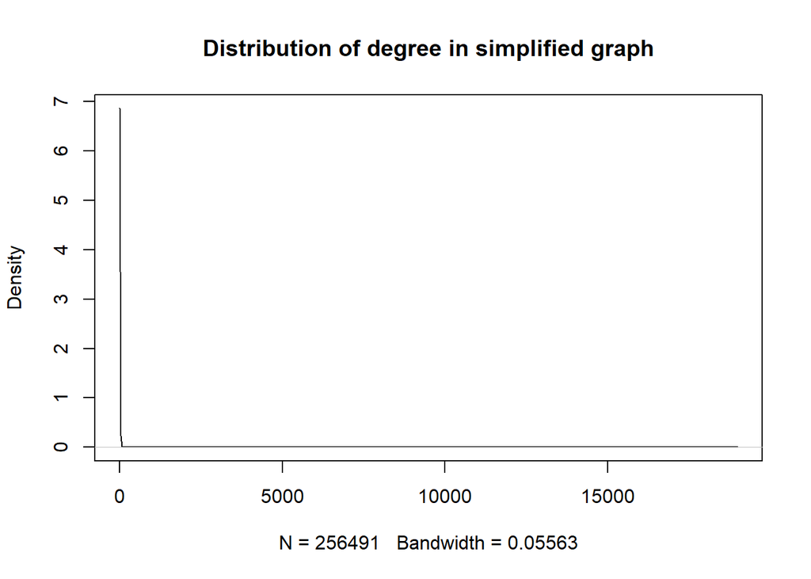

```r
# Getting degree from simplified graph
degs <- degree(g)

# Plotting distribution
plot(density(degs), main = "Distribution of degree in simplified graph")
```

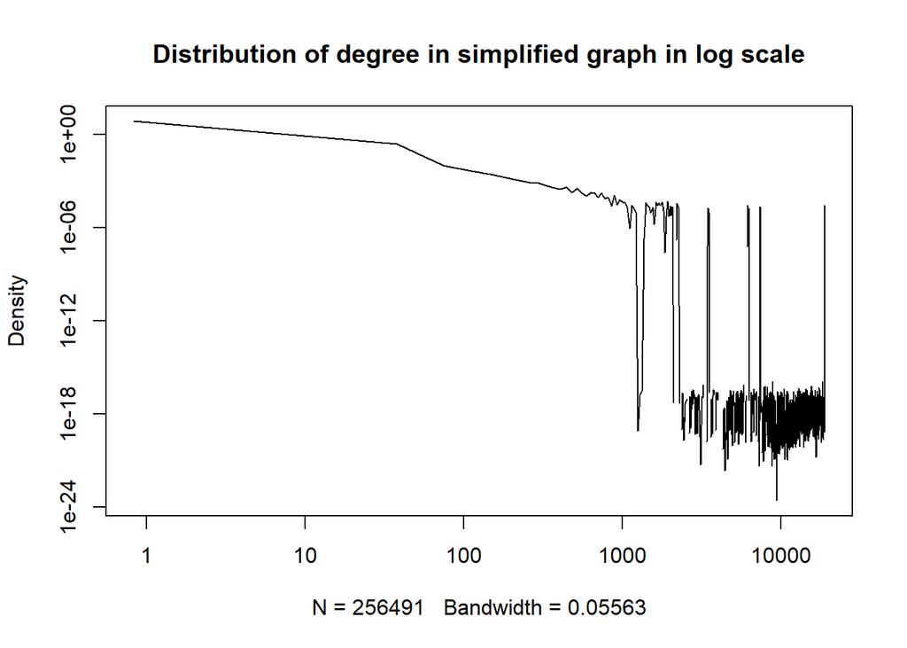

```r
plot(density(degs), log="xy", main = "Distribution of degree in simplified graph in log scale")
```

```r
power.law.fit(degs)
```

```
## $continuous
## [1] FALSE
##
## $alpha
## [1] 2.37813
##
## $xmin
## [1] 1
##
## $logLik
## [1] -289884.2
##
## $KS.stat
## [1] 0.004765064
##
## $KS.p
## [1] 1.747854e-05
```

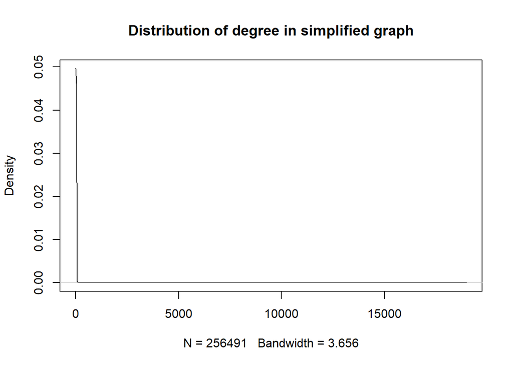

```r
# Getting degree from simplified graph
in_degs <- degree(g, mode = "in")

# Plotting distribution
plot(density(in_degs), main = "Distribution of degree in simplified graph")
```

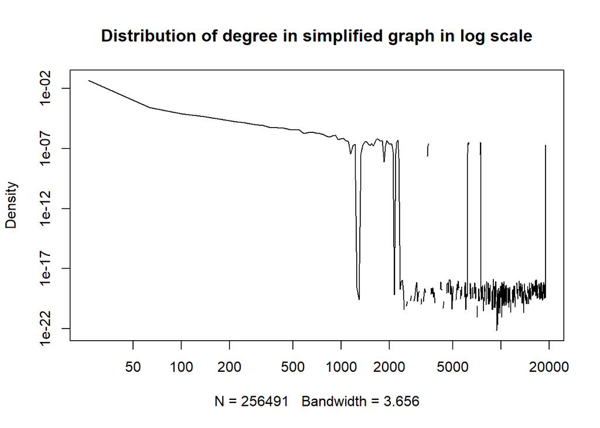

```r
plot(density(in_degs), log="xy", main = "Distribution of degree in simplified graph in log scale")
```

```r
power.law.fit(in_degs)
```

```
## $continuous
## [1] FALSE
##
## $alpha
## [1] 1.900999
##
## $xmin
## [1] 2
##
## $logLik
## [1] -49362.65
##
## $KS.stat
## [1] 0.006258259
##
## $KS.p
## [1] 0.4653967
```

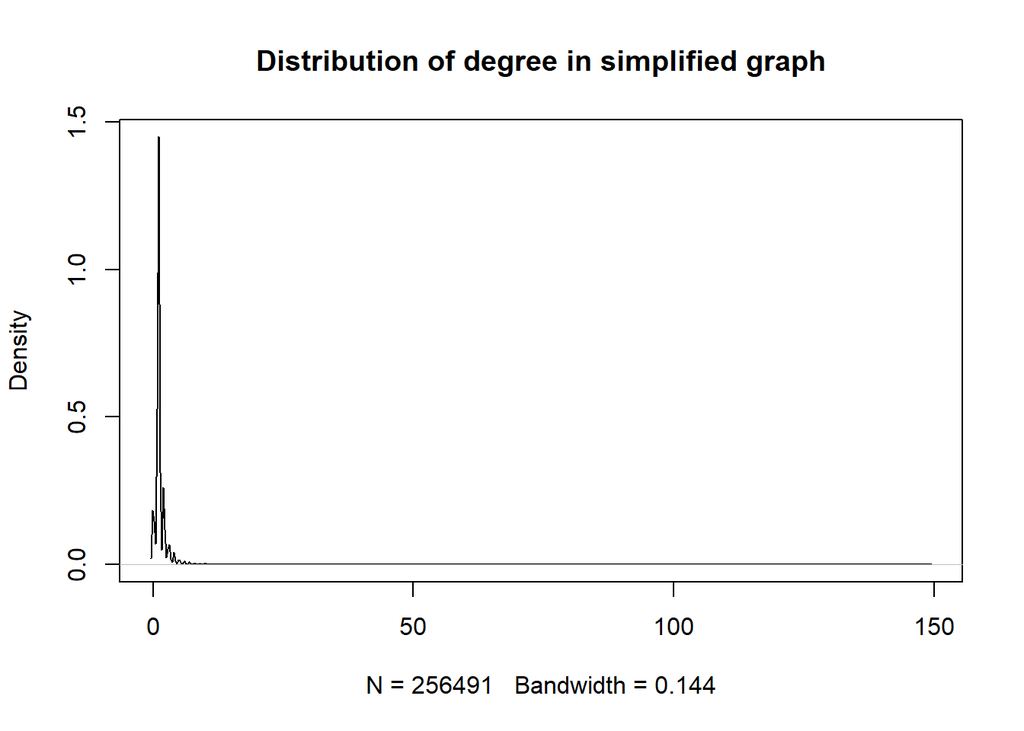

```r
# Getting degree from simplified graph
out_degs <- degree(g, mode = "out")

# Plotting distribution
plot(density(out_degs), main = "Distribution of degree in simplified graph")
```

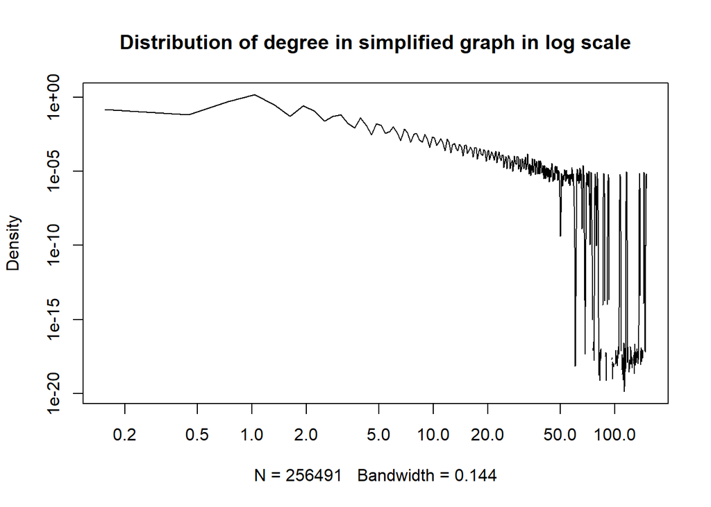

```r
plot(density(out_degs), log="xy", main = "Distribution of degree in simplified graph in log scale")
```

```r
power.law.fit(out_degs)
```

```
## $continuous
## [1] FALSE
##
## $alpha
## [1] 2.934321
##
## $xmin
## [1] 3
##
## $logLik
## [1] -42100.43
##
## $KS.stat
## [1] 0.009200713
##
## $KS.p
## [1] 0.04027281
```

```r
trans_p = transitivity(g,  type="global") * 100
trans_p # Global clustering coeffificent: probability that the adjacent vertices of a vertex are connected
```

```
## [1] 0.03255645
```

```r
reciprocity_p = reciprocity(g, ignore.loops = TRUE) * 100
reciprocity_p # probability that the opposite counterpart of a directed edge is also included in the graph
```

```
## [1] 0.4778407
```

INTERPRETATION: There is 256491 users (nodes) and 354930 retweets (edges) in this network.

For the strong connected component: there is 255002 connected component and 6 types clusters with respectively: one cluster with 984 nodes, one cluster of 32 nodes, one cluster of 17 nodes, one cluster of 14 nodes, one cluster of 11 nodes, and one cluster of 8 nodes.

Our intuition is that there are more connected components for the “strong connected components” than for “weak” because strong connected components are strongly connected together - meaning that a lot of nodes have interaction with each other.

For the inner degree: we have P values (0.46) > 0.05, so we cannot reject H0: follow a power law degree distribution. For the outer degree, it is the opposite, P values (0.04) < 0.05, so we reject H0 meaning that the degree distribution do NOT follow a power law.

## Analyzing communities in a spreading network

In this section, you have to compute communities using two algorithms:

- walktrap.community
- fastgreedy.community

Simplify and consider your graph as undirected if it is needed to figure out communities.

You have to make two visualizations of the network with the results provided by the algorithms. In order to compare both results, keep the same positions for the nodes in both visualizations. Use the *crossing* function to force the visualization layout to place nodes in the same community together.

```r
g2 = as.undirected(simplify(g))

# dirty trick
degs = degree(g2)
inodes = which(degs > 50)
g3 = induced_subgraph(g2, vids=inodes)

# Community
comms = fastgreedy.community(g3)
# other way
comms2 = walktrap.community(g3)

t_comms = table(comms$membership)
t_comms2 = table(comms2$membership)

# coloring  plus grouping nodes per community in viz
# CROSSING: returns a logical vector, with one value for each edge, ordered according to the edge ids. The value is TRUE iff the edge connects two different communities, according to the (best) membership vector, as returned by membership().
crosses = crossing(graph=g3, communities=comms)
crosses2 = crossing(graph=g3, communities=comms2)

E(g3)$weight = ifelse(crosses, 100, 1)

# cmputing layout
ll = layout.fruchterman.reingold(g3)
colpal = sample(rainbow(max(comms$membership)))
cols = colpal[comms$membership]

png("tt_fast_greedy.png",width=800, height=800)
  plot(x = comms, y = g3, edge.width = 1, vertex.size = 4, vertex.label = NA, mark.groups = NULL, layout = ll, col= cols,main = "Communities in retweet network - Fast greedy")
dev.off()
```

```r
colpal = sample(rainbow(max(comms2$membership)))
cols = colpal[comms2$membership]

png("tt_walktrap.png",width=800, height=800)
  plot(x = comms2, y = g3, edge.width = 1, vertex.size = 4, vertex.label = NA, mark.groups = NULL, layout = ll, col= cols,main = "Communities in retweet network - walk trap")
dev.off()
```

Compare also two metrics to check which algorithm provides the best result and discuss your choice:

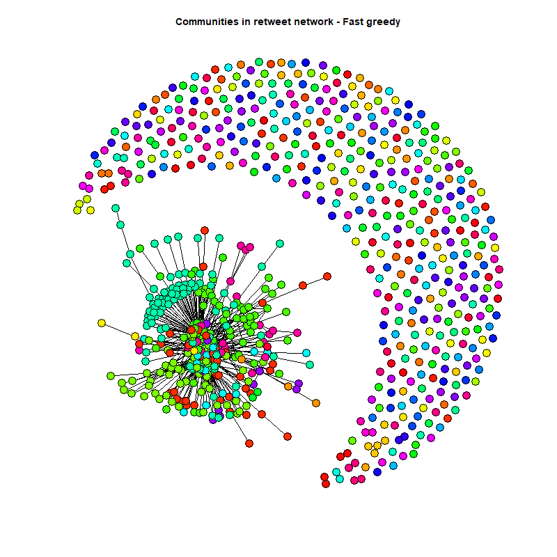

Fast Greedy

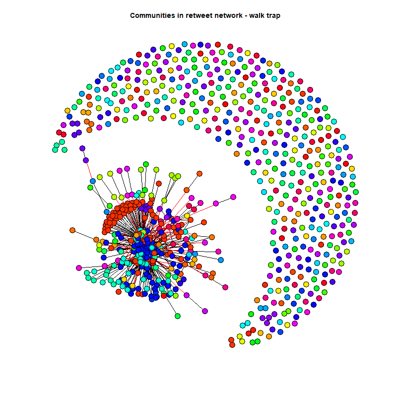

Walk Tarp

However, if we were forced to choose between one or the other method, we would go for Walktrap method. Since it takes “random walks”, I might give a better representation of the network because Fast greedy has a tendency to merge neighboring communities together if they are below a certain thresold. In Addition, it is more accurate that fast greedy (according to the origninal paper).

source:https://stackoverflow.com/questions/9471906/what-are-the-differences-between-community-detection-algorithms-in-igraph

Note: with the graphs we can visually see that the transitivity ratio is pretty low, since there are a lot of single nodes unconnected.

```r
# function to calculate internal density for each community
int_den <- function(comm, g) {
  # empty dataframe
  int_den_df <- data.frame(community = numeric(), density = numeric(), members_num = numeric())

  for(i in 1:length(comm)) {
    members <- comm$names[comm$membership == i]
    total_possible_links <- length(members) * (length(members) - 1) / 2 #inclass formulas
    total_actual_links <- ecount(induced_subgraph(g, members))
    int_den_df <- rbind(int_den_df, data.frame(community = i, density = total_actual_links/total_possible_links, members_num = length(members)))
  }
  return(int_den_df)
}

# compute internal density of each community
comm_fg_int_den <- int_den(comms, g3)
comm_wt_int_den <- int_den(comms2,  g3)

#print communitties by asceding order of density
head(comm_fg_int_den[order(comm_fg_int_den$density),],10)
```

```
##    community    density members_num
## 2          2 0.02398485          98
## 1          1 0.04040404          55
## 6          6 0.06849315          74
## 3          3 0.07299553         102
## 4          4 0.09486166          23
## 5          5 0.14285714          15
## 7          7 0.15384615          14
## 8          8 0.16666667          12
## 10        10 0.50000000           4
## 11        11 0.50000000           4
```

```r
head(comm_wt_int_den[order(comm_wt_int_den$density),],10)
```

```
##    community    density members_num
## 1          1 0.04429825          96
## 2          2 0.04686343         138
## 5          5 0.10695187          34
## 8          8 0.25000000           8
## 15        15 0.25000000           8
## 10        10 0.30555556           9
## 3          3 0.33333333           6
## 11        11 0.40000000           5
## 12        12 0.40000000           5
## 13        13 0.40000000           5
```

```r
# function to calculate external density for each community
ext_den <- function(comm, g, cross) {
  # empty dataframe
  ext_den_df <- data.frame(community = numeric(), density = numeric(), members_num = numeric())

  for(i in 1:length(comm)) {
    members <- comm$names[comm$membership == i]
    ext_links <- length(E(g)[cross][from(members)])

    cluster_nodes <- vcount(induced_subgraph(g, members))
    all_links <- (cluster_nodes * (vcount(g) - cluster_nodes))

    ext_den_df <- rbind(ext_den_df, data.frame(community = i, density = ext_links/all_links, members_num = length(members)))
  }
  return(ext_den_df)
}

# compute external density of each community
comm_fg_ext_den <- ext_den(comms, g3, crosses)
comm_wt_ext_den <- ext_den(comms2, g3, crosses2)


# order results by number of members and higher density community first
head(arrange(comm_fg_ext_den, desc(members_num), desc(density)),10)
```

```
##    community      density members_num
## 1          3 0.0027553505         102
## 2          2 0.0013932751          98
## 3          6 0.0017211411          74
## 4          1 0.0022839230          55
## 5          4 0.0011848341          23
## 6          5 0.0024256651          15
## 7          7 0.0012560710          14
## 8          8 0.0006822612          12
## 9          9 0.0002590003           9
## 10        10 0.0014484357           4
```

```r
head(arrange(comm_wt_ext_den, desc(members_num), desc(density)),10)
```

```
##    community      density members_num
## 1          2 0.0023756983         138
## 2          1 0.0019860571          96
## 3          5 0.0035661323          34
## 4         10 0.0011655012           9
## 5         52 0.0002590003           9
## 6          8 0.0024738068           8
## 7         15 0.0023282887           8
## 8          3 0.0017421603           6
## 9         12 0.0009280742           5
## 10        13 0.0006960557           5
```

```r
# communities with at least 1 external connection
dim(comm_fg_ext_den[comm_fg_ext_den$density != 0.0,])
```

```
## [1] 16  3
```

```r
dim(comm_wt_ext_den[comm_wt_ext_den$density != 0.0,])
```

```
## [1] 56  3
```

## Analyzing how the spreading works

In this section, we have to describe how the spreading has evolved:

- Plot a graph showing the number of infected nodes on time (an infected node is a node who has published content - it is in the graph but we see no retweets from him but people retweet his content - or a node who has retweeted a tweet). Describe what you see.

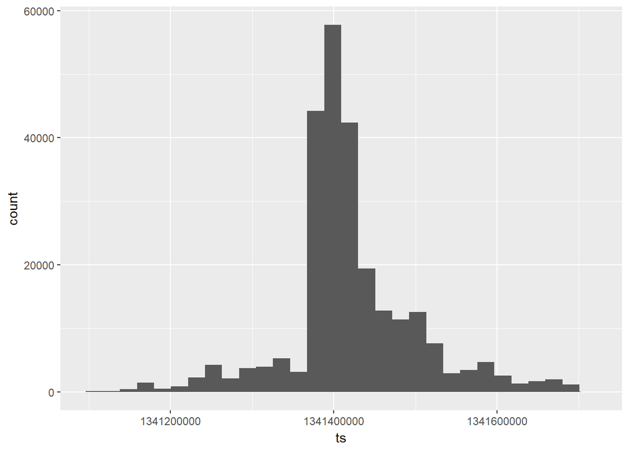

```r
#cummulative sum of infection over time (1 hour binning)

df1 = df %>%
  group_by(user1) %>%
  summarize(min_ts = min(ts)) %>%
  rename(user = user1)

df2 = df %>%
  group_by(user2) %>%
  summarize(min_ts = min(ts)) %>%
  rename(user = user2)

users = rbind(df1,df2)

users = users %>%
  group_by(user) %>%
  summarize(ts = min(min_ts))


ggplot(users, aes(x=ts))+ geom_histogram() +
    stat_bin(aes(y=..count..), breaks=seq(1341101181,1341705593,3600))
```

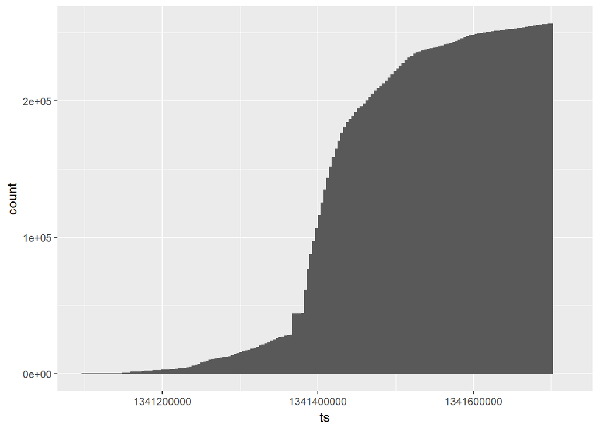

```r
ggplot(users, aes(x=ts))+ geom_histogram() +
    stat_bin(aes(y=cumsum(..count..)), breaks=seq(1341101181,1341705593,3600))
```

INTERPRETATION: Looking at the first graph we can see that the distribution of the spreadness is not gaussian and it has a high pick around 1341400000 ts. Therefore, indicating that around that time, there is a lot of retweet.

The second graph clearly reveals interesting facts: at the beginning the infection is minimal with a slow increase, then it suddenly increases rapidly (which also correspond to the highest point of the first graph) to finally stabilized at time 134160000 where the increase rate is marginal.

- Compute the reproduction number (how many infected nodes on average appear from a previous infected node?). How this number evolve in time (for a given time, considering only past interactions)?

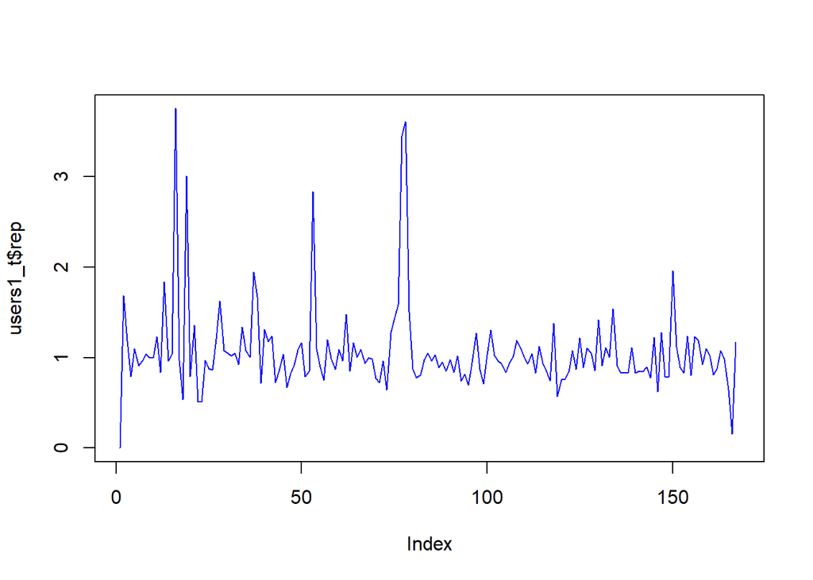

```r
users1 = users %>%
  mutate(ts_cat = cut(ts, breaks = seq(1341101181,1341705593,3600), labels = c(1:167)))

users1$ts_cat = as.numeric(users1$ts_cat)

users1_t = as.data.frame(table(users1$ts_cat))

users1_t$rep = 0
for (i in c(1:167)){
  users1_t[i+1,]$rep = users1_t[i+1,]$Freq/users1_t[i,]$Freq
}

plot(users1_t$rep, type="l", col="blue")
```

```r
#with cumulative appreance
# temp = 0
# users1_t$rep2 = 0
# for (i in c(1:167)){
#   temp = temp + users1_t[i,]$Freq
#   users1_t[i+1,]$rep2 = users1_t[i+1,]$Freq/temp
# }
#
# plot(users1_t$rep2, type="l", col="blue")
```

However, the last spike last for long, meaning that the same among of retweet happened but for a longer period (snowball effect). After that, the infection is “stable” around 1 (excluding the outliers of index 150 and 160).

- Visualize the longest cascade: considering links that infect new nodes (nodes that have not previously appeared in the spreading), create the subgraph and visualize it.

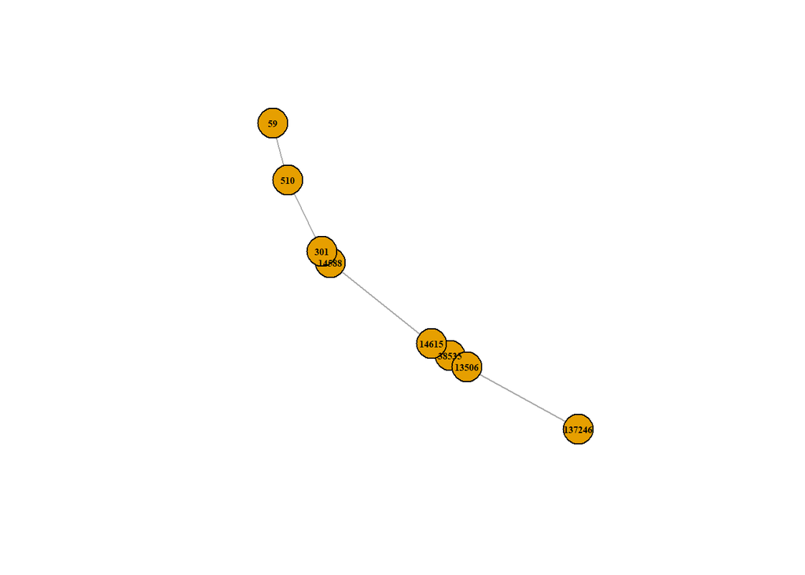

```r
# use simplified graph used before to find the longest cascade
# find the longest distanced vertices from the simplifed graph
longest_vertices <- farthest_vertices(g3)

# get the shortest_path for the verticies find above
shortest <- get.shortest.paths(g3, from = longest_vertices$vertices[1],
                   to = longest_vertices$vertices[2])

# induce subgraph of the longest cascade
longest_cascade <- induced.subgraph(g3, shortest$vpath[[1]])

# plot longest cascade
plot(longest_cascade, edge.arrow.size = 0.5,
     vertex.label.cex = 0.5, vertex.label.color = 'black', vertex.label.font = 2,
     vertex.size = 20)
```